# FinalProject

# Yelp Fusion API: Analysis #2, Text Analysis

## Test run

### Setup for access to the Yelp Fusion, Reviews API which includes business reviews, url, rating, time_created, user, user name, and user image url. The parameter, locale, determines the language of reviews to return (default is English). The API allows 3 review excerpts of 160 characters, and use a variety of factors to determine and return a business’s top review excerpts which can not be altered. The loop below only pulls one per business. See, https://www.yelp.com/developers/faq for more information.

```r
#Documentation: https://www.yelp.com/developers/documentation/v3/business_reviews
#Yelp Fusion, Reviews API: This endpoint returns the up to three reviews of a business.
##Note: at this time, the API does not return businesses without any reviews.
#Endpoint: https://api.yelp.com/v3/businesses/{id}/reviews

yelp_fusionr <- "https://api.yelp.com"
yfr <- data.frame()
for(i in 1:20) {
  (url2 <- modify_url(
    yelp_fusionr,
    path = c("v3", "businesses", "housing-works-bookstore-cafe-new-york-3", "reviews")
    )
  )

  h = GET(url2, add_headers('Authorization' = paste("Bearer", token)))
  j = content(h)
  k = jsonlite::fromJSON(toJSON(j))

  yf_outputr = tryCatch({
    data.frame(j)
  }, error = function(e) {
    NULL
  })

  if (!is.null(yf_outputr)) {
    yfr <-
      rbind(
        yfr,
        data.frame(
          'name' = unlist(yf_outputr$reviews.user.name),
          'text' = unlist(yf_outputr$reviews.text),
          'rating' = unlist(yf_outputr$reviews.rating),
          'url' = unlist(as.character(yf_outputr$reviews.url))
        )
      )
  }
}

yfr <- yfr %>%
  distinct(name, .keep_all = TRUE)

yfr
```

```
##        name
## 1 Daniel M.
##                                                                                                                                                           text
## 1 I found this place using Yelp! I was happy I visited this place as I found a relaxing atmosphere and welcoming staff. Their are plenty of books to choose...
##   rating
## 1      5
##                                                                                                                                                                                                                                      url
## 1 https://www.yelp.com/biz/housing-works-bookstore-caf%C3%A9-new-york-3?hrid=YLy7pufhfWRFvq39WWbUkA&adjust_creative=8ca1LRQedoZBtKwoKpG8ZA&utm_campaign=yelp_api_v3&utm_medium=api_v3_business_reviews&utm_source=8ca1LRQedoZBtKwoKpG8ZA
```

# Yelp Fusion API: Analysis #2, Text Analysis

## Loop for full list of reviews from Yelp Fusion, Reviews API for specified business: “coffee” in “New York, NY”.

```r
f <- data.frame()
for(i in 1:x){
  url2 <- final_url_list[i]
  if(url2=="") {
    warning("error") }
    else {
  a <- GET(url2, add_headers('Authorization' = paste("Bearer", token)))
  b <- content(a)
  c <- jsonlite::fromJSON(toJSON(b))

  d = tryCatch({
    data.frame(b)
  }, error = function(e) {
    NULL
  })

  if (!is.null(d)) {
    f <-
      rbind(
        f,
        data.frame(
          'user_name' = unlist(d$reviews.user.name),
          'text' = unlist(d$reviews.text),
          'rating' = unlist(d$reviews.rating),
          'url' = unlist(as.character(d$reviews.url))
        )
      )
  }
}}

f <- f %>%
  distinct(name, .keep_all = TRUE)
```

# Yelp Fusion API: Analysis #2, Text Analysis

```r
#extract id

id3 <- stri_match_first_regex(f$url, "(.*?)\\?")[,2]

id2 <- substring(id3, regexpr("z/", id3) + 1)

id1 <- substring(id2, regexpr("/", id2) + 1)

#add as a column to f.db

f$id<- id1
f
```

```
##                user_name
## 1               Susan Y.
## 2             Brandon K.
## 3             anthony r.
## 4            Fallopia T.
## 5              Hailey K.
## 6              Adrian M.
## 7             Pauline K.
## 8                 Mee Y.
## 9              Debora C.
## 10               Elle L.
## 11            Huining Z.
## 12                Ivy E.
## 13               Rick S.
## 14               Sara B.
```

[output cut: 3475 more lines]

```r
save(f, file = "Yelp_Coffee_TextReviews_Data.rda")
load("Yelp_Coffee_TextReviews_Data.rda")
```

# Yelp Fusion API: Analysis #2, Text Analysis

```r
Yelp_full <- inner_join(f, yf, by = "id")
save(Yelp_full, file = "Yelp_Coffee_Full_Data.rda")
load("Yelp_Coffee_Full_Data.rda")
```

# Yelp Fusion API: Analysis #2, Text Analysis

## Text mining technique using Tidytext.

### Plot shows count associated with each word (limited to n>20) from excerpts of 1 review per business.

```r
text1 <- Yelp_full %>%
  select_(text = "text")

tn <- nrow(text1)

class(text1)
```

```
## [1] "data.frame"
```

```r
text2 <- data.frame(lapply(text1, as.character), stringsAsFactors=FALSE)

text_df <- data.frame(line = 1:tn, text2)
text_df
```

```
##     line
## 1      1
## 2      2
## 3      3
## 4      4
## 5      5
## 6      6
## 7      7
## 8      8
## 9      9
## 10    10
## 11    11
## 12    12
## 13    13
## 14    14
```

[output cut: 1309 more lines]

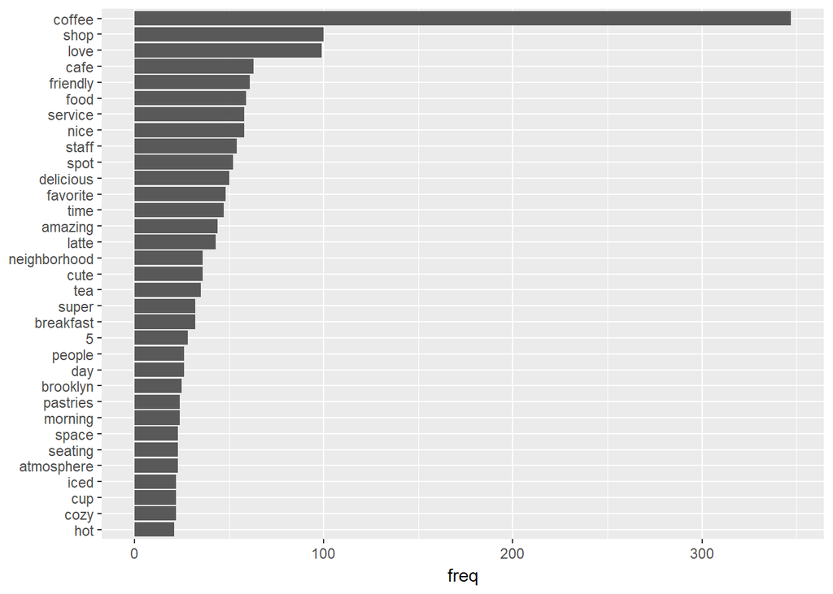

```r
##tidytext stop words
data(stop_words)

plot_tcount <- text_df %>%
  unnest_tokens(word, text) %>%
  anti_join(stop_words, by=c("word"="word")) %>%
  count("word", wt_var = NULL) %>%
  filter(freq > 20) %>%
  arrange(desc(freq)) %>%
  mutate(word = reorder(word, freq)) %>%
  ggplot(aes(word, freq)) +
  geom_col() +
  xlab(NULL) +
  coord_flip()

plot_tcount
```

# Yelp Fusion API: Analysis #2, Text Analysis ## Text mining techniques (NCR & Bing) “constructed via either crowdsourcing (using, for example, Amazon Mechanical Turk) or by the labor of one of the authors, and were validated using some combination of crowdsourcing again, restaurant or movie reviews, or Twitter data”, http://tidytextmining.com/tidytext.html. ### Plot shows count of words per “NCR” sentiment: joy, fear, negative, sadness, anger, surprise, positive, disgust, anticipation, and trust. Sentiments such as positive, joy, and trust appear the most popular which indicate overall high/satisfactory quality for coffee shops in New York.

```r
#learn NCR sentiments and sum words from Yelp reviews per sentiment
ncr <- get_sentiments("nrc")
ncr_sent_groupings <- unique(ncr$sentiment, incomparables = FALSE)
ncr_sent_groupings
```

```
##  [1] "trust"        "fear"         "negative"     "sadness"
##  [5] "anger"        "surprise"     "positive"     "disgust"
##  [9] "joy"          "anticipation"
```

```r
nrc_joy <- get_sentiments("nrc") %>%
  filter(sentiment == "joy")
nrc_fear <- get_sentiments("nrc") %>%
  filter(sentiment == "fear")
nrc_negative <- get_sentiments("nrc") %>%
  filter(sentiment == "negative")
nrc_sadness <- get_sentiments("nrc") %>%
  filter(sentiment == "sadness")
nrc_anger <- get_sentiments("nrc") %>%
  filter(sentiment == "anger")
nrc_surprise <- get_sentiments("nrc") %>%
  filter(sentiment == "surprise")
nrc_positive <- get_sentiments("nrc") %>%
  filter(sentiment == "positive")
nrc_disgust <- get_sentiments("nrc") %>%
  filter(sentiment == "disgust")
nrc_anticipation <- get_sentiments("nrc") %>%
  filter(sentiment == "anticipation")
nrc_trust <- get_sentiments("nrc") %>%
  filter(sentiment == "trust")

ncr_sent_joy <- text_df %>%
  unnest_tokens(word, text) %>%
  inner_join(nrc_joy) %>%
  count("word", wt_var = NULL)
joy <- sum(ncr_sent_joy$freq)
joy
```

```
## [1] 848
```

```r
ncr_sent_fear <- text_df %>%
  unnest_tokens(word, text) %>%
  inner_join(nrc_fear) %>%
  count("word", wt_var = NULL)
fear <- sum(ncr_sent_fear$freq)
fear
```

```
## [1] 95
```

```r
ncr_sent_negative <- text_df %>%
  unnest_tokens(word, text) %>%
  inner_join(nrc_negative) %>%
  count("word", wt_var = NULL)
negative <- sum(ncr_sent_negative$freq)
negative
```

```
## [1] 313
```

```r
ncr_sent_sadness <- text_df %>%
  unnest_tokens(word, text) %>%
  inner_join(nrc_sadness) %>%
  count("word", wt_var = NULL)
sadness <- sum(ncr_sent_sadness$freq)
sadness
```

```
## [1] 144
```

```r
ncr_sent_anger <- text_df %>%
  unnest_tokens(word, text) %>%
  inner_join(nrc_anger) %>%
  count("word", wt_var = NULL)
anger <- sum(ncr_sent_anger$freq)
anger
```

```
## [1] 140
```

```r
ncr_sent_surprise <- text_df %>%
  unnest_tokens(word, text) %>%
  inner_join(nrc_surprise) %>%
  count("word", wt_var = NULL)
surprise <- sum(ncr_sent_surprise$freq)
surprise
```

```
## [1] 269
```

```r
ncr_sent_positive <- text_df %>%
  unnest_tokens(word, text) %>%
  inner_join(nrc_positive) %>%
  count("word", wt_var = NULL)
positive <- sum(ncr_sent_positive$freq)
positive
```

```
## [1] 1382
```

```r
ncr_sent_disgust <- text_df %>%
  unnest_tokens(word, text) %>%
  inner_join(nrc_disgust) %>%
  count("word", wt_var = NULL)
disgust <- sum(ncr_sent_disgust$freq)
disgust
```

```
## [1] 96
```

```r
ncr_sent_anticipation <- text_df %>%
  unnest_tokens(word, text) %>%
  inner_join(nrc_anticipation) %>%
  count("word", wt_var = NULL)
anticipation <- sum(ncr_sent_anticipation$freq)
anticipation
```

```
## [1] 569
```

```r
ncr_sent_trust <- text_df %>%
  unnest_tokens(word, text) %>%
  inner_join(nrc_trust) %>%
  count("word", wt_var = NULL)
trust <- sum(ncr_sent_trust$freq)
trust
```

```
## [1] 716
```

```r
sentiment_scores <- as.data.frame(cbind(trust, anger, anticipation, disgust, fear, joy, negative, positive, sadness, surprise))

sentiment_scores.df <- melt(sentiment_scores)
sentiment_scores.df <- sentiment_scores.df %>%
  arrange(desc(value))

sentiment_scores.df
```

```
##        variable value
## 1      positive  1382
## 2           joy   848
## 3         trust   716
## 4  anticipation   569
## 5      negative   313
## 6      surprise   269
## 7       sadness   144
## 8         anger   140
## 9       disgust    96
## 10         fear    95
```

```r
##arrange bars in order

sentiment_scores.df$variable <- factor(sentiment_scores.df$variable, levels = sentiment_scores.df$variable[order(sentiment_scores.df$value)])
sentiment_scores.df$variable
```

```
##  [1] positive     joy          trust        anticipation negative
##  [6] surprise     sadness      anger        disgust      fear
## 10 Levels: fear disgust anger sadness surprise negative ... positive
```

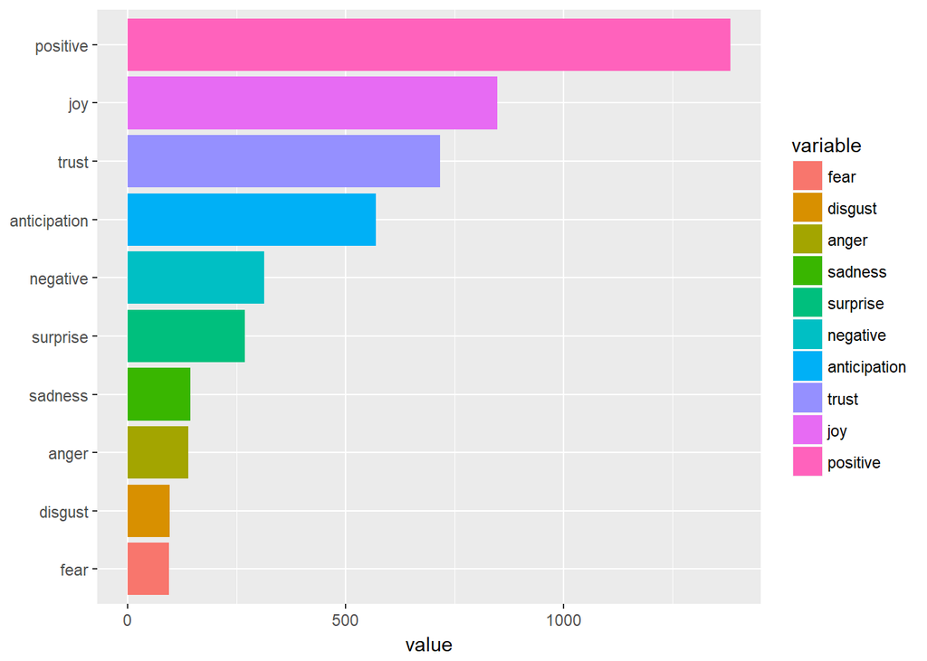

```r
plot_scount <- sentiment_scores.df %>%
  ggplot(aes(variable, value, fill=variable)) +
  geom_col() +
  xlab(NULL) +
  coord_flip() +
  geom_bar(stat = "identity")

plot_scount
```

# Yelp Fusion API: Analysis #2, Text Analysis ## Text mining techniques (NCR & Bing) “constructed via either crowdsourcing (using, for example, Amazon Mechanical Turk) or by the labor of one of the authors, and were validated using some combination of crowdsourcing again, restaurant or movie reviews, or Twitter data”, http://tidytextmining.com/tidytext.html. ### Plot shows count of words per “Bing” sentiment: positive, negative, and overall sentiment (postive - negative).

```r
bing <- get_sentiments("bing")

bing_sentiment <- text_df %>%
  unnest_tokens(word, text) %>%
  inner_join(get_sentiments("bing"), by=c("word"="word")) %>%
  count("sentiment", wt_var = NULL)

net_sentiment <- bing_sentiment %>%
  mutate(netsentiment = freq - first(freq))

net_sentiment1 <- net_sentiment$netsentiment

net_sentiment2 <- net_sentiment1[2]

bing_sentiment_scores <- as.data.frame(rbind(bing_sentiment, net_sentiment2))

bing_sentiment_scores$sentiment <- with(bing_sentiment_scores, ifelse(sentiment=="1338", "net sentiment", sentiment))
bing_sentiment_scores
```

```
##   sentiment freq
## 1  negative  261
## 2  positive 1598
## 3      1337 1337
```

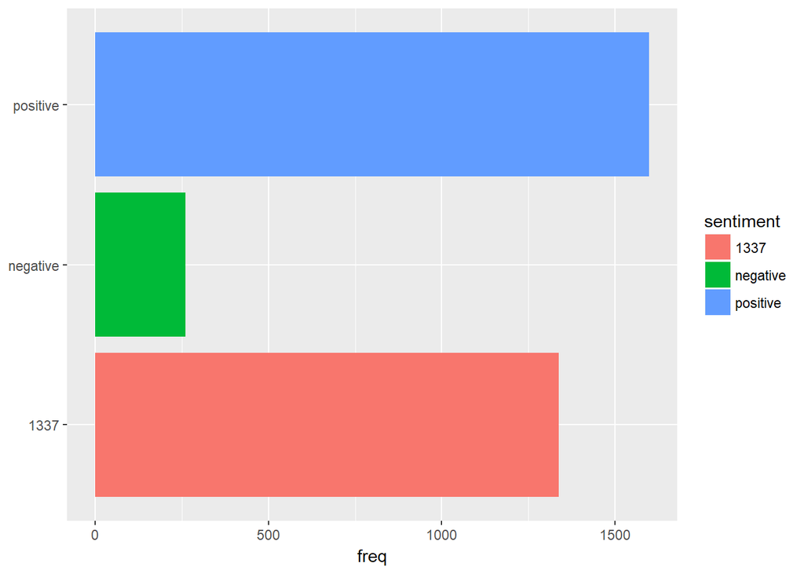

```r
##plot

plot_bcount <- bing_sentiment_scores %>%
  ggplot(aes(sentiment, freq, fill=sentiment)) +
  geom_col() +
  xlab(NULL) +
  coord_flip() +
  geom_bar(stat = "identity")

plot_bcount
```